# Pomiar efektywnego współczynnika reprodukcji R dla COVID-19 w Polsce

### **Rafał J. Mostowy**

#### Małopolskie Centrum Biotechnologii Uniwersytetu Jagiellońskiego, Kraków, Polska

#### Data ostatniej aktualizacji: 04/11/2020

#### Adres korespondencyjny: rafal.mostowy@uj.edu.pl

## Wprowadzenie

Pandemia COVID-19 rozpoczęła się w Polsce oficjalnie 4 marca 2020, kiedy to został zarejestrowany i potwierdzony pierwszy przypadek osoby zakażonej wirusem SARS-CoV-2. Jednym z kluczowych parametrów rozwoju epidemii jest tzw. *współczynnik reprodukcji* $R$, który jest miarą średniej ilości drugorzędnych zakażeń przez jedną osobę zakażoną podczas cyklu infekcji. Gdy $R>1$, epidemia rozwija się, ponieważ liczba przypadków namnaża się; gdy $R<1$ epidemia wygasa, ponieważ zakażonych ubywa szybciej, niż przybywa; gdy $R\sim1$ mamy do czynienia z sytuacją endemiczną. Na samym początku epidemii, czyli gdy $t=0$, populacja jest zazwyczaj całkowicie podatna na infekcję i wtedy mówimy o bazowym współczynniku reprodukcji $R_0$, który często interpretowany jest jako stopień zakaźności danej choroby (porównanie wartości $R_0$ dla różnych chorób zakaźnych można prezczytać na [Wikipedii](https://en.wikipedia.org/wiki/Basic_reproduction_number)). Potem, gdy wirus rozprzestrzeni się w populacji, mamy do czynienia z **efektywnym współczynniku reprodukcji**, $R(t)$, który określa obecny stan rozwoju epidemii.

Szacowanie $R(t)$ w praktyce jest skomplikowane, ponieważ opiera się na dopasowaniu modeli matematycznych, opartych na wielu założeniach, do (często niedoskonałych) danych epidemicznych. Takie modele bardzo często nie nadają się do szacowania parametru $R(t)$ w czasie rzeczywistym, a ich zastosowanie do tego typu obliczeń może spowodować w niedoszacowanie lub przeszacowanie tego parametru [1]. Żeby zminimalizować ten problem, zalecane są więc metody, które opierają się na pomiarze dynamiki zakażeń w czasie rzeczywistym na podstawie empirycznego rozkładu czasu pomiędzy dwoma następującymi po sobie przypadkami zakażeń (tzw. interwał seryjny) opracowanego przez Anne Cori et al. [2]. Używając tego podejścia, tutaj szacuję parametr $R(t)$ zakładając średni interwał seryjny w o średniej wartości 3.96 dnia oraz odchylenia standardowego w wysokości 4.75 dnia [3-4]. Pomiar wykonuję dla całej Polski oraz poszczególnych województw bazując na danych dotyczących liczby osób z potwierdzonym zakażeniem wirusa podawanych do informacji publicznej przez Ministerstwo Zdrowia poprzez [stronę internetową](https://www.gov.pl/web/koronawirus) oraz [media społecznościowe](https://twitter.com/MZ_GOV_PL), zebranych i upublicznionych przez pana [Michała Rogalskiego](https://twitter.com/micalrg) pod [tym linkiem](https://docs.google.com/spreadsheets/d/1ierEhD6gcq51HAm433knjnVwey4ZE5DCnu1bW7PRG3E/edit#gid=1400401584). Analiza ta uwzględnia dane aż do 04/11/2020. Kod użyty do tych analiz można pobrać pod [następującym linkiem](https://github.com/rmostowy/rmostowy.github.io/tree/master/covid-19/code/v3).

## Wyniki

### Jak współczynnik reprodukcji R(t) zmieniał się w czasie w Polsce?

Wykres przedstawia $R(t)$ szacowane w czasie rzeczywistym (wartość średnia plus przedział nieufności statystycznej 95%).

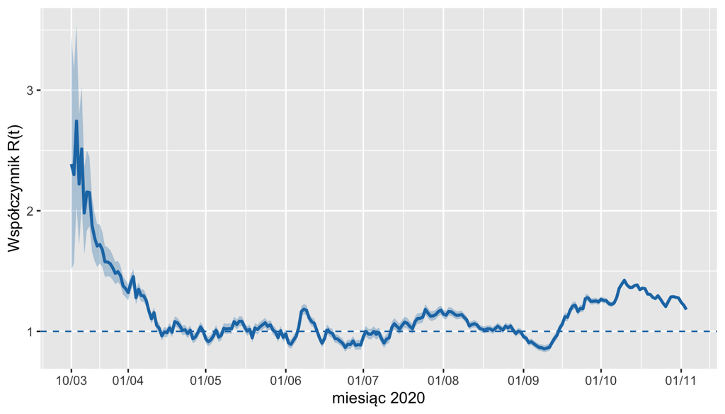

### Jak współczynnik reprodukcji R(t) zmieniał się w czasie w różnych województwach?

Jak wyżej tylko z podziałem na 16 województw.

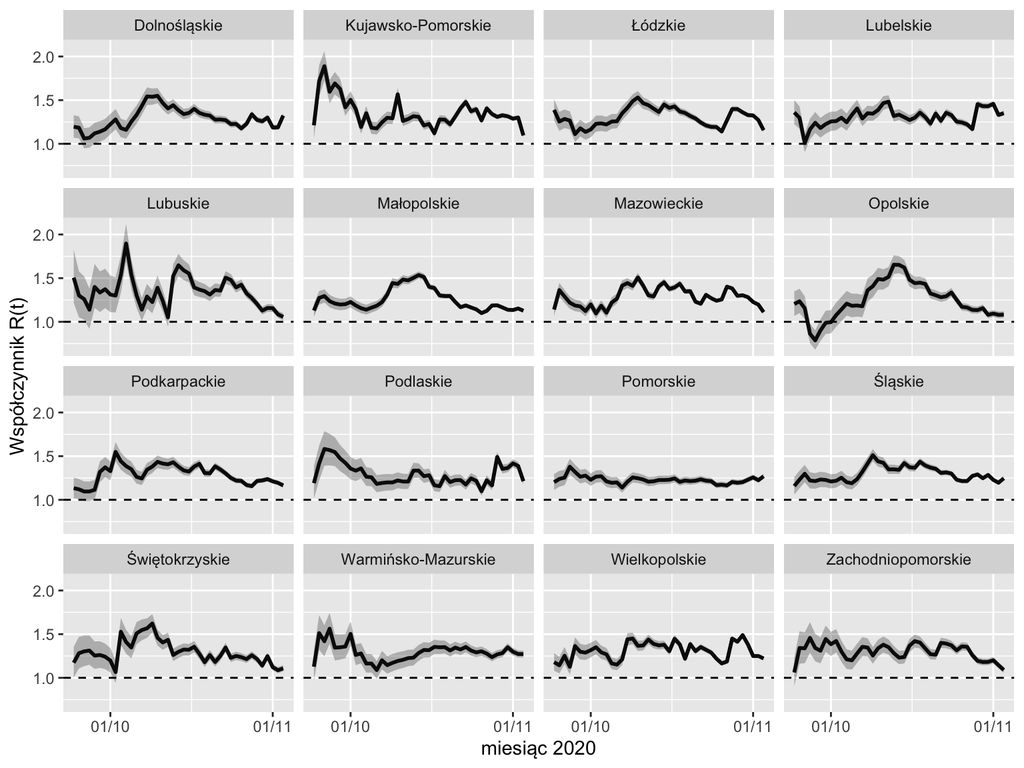

### Jak wyglądają najnowsze szacunki współczynnika reprodukcji R(t)?

Obecna wartość $R(t)$ dla Polski wynosi 1.18 (95% CI: 1.17 - 1.19). Poniżej porównanie tego szacunku (lewa strona) z poszczególnymi województwami.

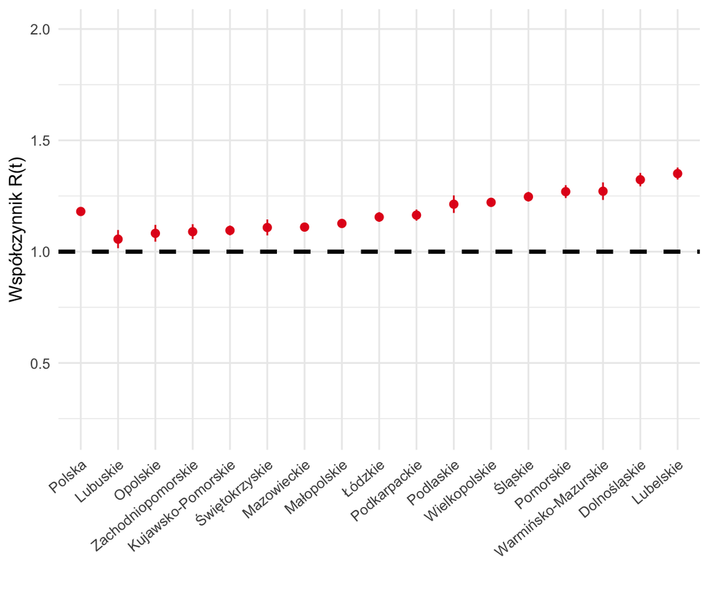

## Najczęściej zadawane pytania (FAQ)

- **Czy ten model może posłużyć do predykcji pandemii COVID-19 w Polsce?** Niestety nie. Ta analiza służy jedynie do pomiaru obecnej sytuacji epidemicznej, a konkretnie tego, czy epidemia się rozwija czy zanika. Z pandemią jest trochę jak z giełdą, mianowicie przyszłość w dużym stopniu zależy od naszych reakcji na obecną sytuację (np. indywidualnych zachowań lub interwencji rządowych). Dlatego nawet najlepsza prognoza sprawdzi się przez co najwyżej kilka dni.
- **Jakie są główne założenia tej analizy?** Najważniejszym założeniem jest to, że ilość wykrywanych zakażeń jest reprezentatywna względem wszystkich przypadków w Polsce. W praktyce liczba wykonwywanych testów zmienia się każdego dnia (choć od jakiegoś czasu utrzymuje się na stosunkowo stabilnym poziomie). Spodziewamy się też, że osoby symptomatyczne z większym prawdopodobieństwem wykryją u siebie zakażenie.

## Referencje

1. Practical considerations for measuring the effective reproductive number, Rt. Katelyn M Gostic, Lauren McGough, Edward Baskerville, Sam Abbott, Keya Joshi, Christine Tedijanto, Rebecca Kahn, Rene Niehus, James A Hay, Pablo M. De Salazar, Joel Hellewell, Sophie Meakin, James Munday, Nikos Bosse, Katharine Sherratt, Robin M Thompson, Laura F White, Jana Huisman, Jérémie Scire, Sebastian Bonhoeffer, Tanja Stadler, Jacco Wallinga, Sebastian Funk, Marc Lipsitch, Sarah Cobey. medRxiv 2020.06.18.20134858
2. Cori, A., Ferguson, N. M., Fraser, C., & Cauchemez, S. (2013). A new framework and software to estimate time-varying reproduction numbers during epidemics. American journal of epidemiology, 178(9), 1505-1512.
3. Du, Z., Xu, X., Wu, Y., Wang, L., Cowling, B. J., & Meyers, L. A. (2020). Serial interval of COVID-19 among publicly reported confirmed cases. Emerging infectious diseases, 26(6), 1341.
4. Nishiura, H., Linton, N. M., & Akhmetzhanov, A. R. (2020). Serial interval of novel coronavirus (COVID-19) infections. International journal of infectious diseases.